# Christian Gardner IT Salary Analysis

### Import Necesarry Libraries

```r
library(tidyverse)
library(mosaic)
library(party)
```

### Research Question

1. What is the highest paying tech or STEM related jobs? (Titles, sectors, etc.)
2. What are some of the highest paying companies to work for? (And the lowest?) Alternate Question
3. How does this compare to Europe?
4. What are the highest paying IT/Developer Jobs in Europe?

### Examine Data source

MAIN DATASET

- Over 62,000 tech and STEM salary data points scraped off of levels.fyi which is a website that helps tech employees negotiate fair salaries
- The purpose of the data originally is that potential employees of large tech companies can see what comptetitors and coworkers make
- For this project’s purposes however, this data was scraped off of the levels.fyi and in a csv file on Kaggle
- The dataset contains useful information such as education level, salary, race, and more
- Includes 29 variables, many of which will be removed for the purposes of this project
- There are categorical variables such as job title and numerical variables such as salary or years of experience

ALTERNATE DATASET 1. Anonymous survey among European IT Specialists (strong focus in Germany)

### Import Main Dataset

```r
US_Salary <- read.csv("Levels_Fyi_Salary_Data.csv")
```

### Import Alternate Dataset (Store dataset in repo as well)

```r
eu_salary <- read.csv("IT_EU_SALARY_2020.csv")
```

### Insight into Data

```r
glimpse(US_Salary)
```

```
Rows: 62,642
Columns: 29
$ timestamp               <chr> "6/7/2017 11:33:27", "6/1~
$ company                 <chr> "Oracle", "eBay", "Amazon~
$ level                   <chr> "L3", "SE 2", "L7", "M1",~
$ title                   <chr> "Product Manager", "Softw~
$ totalyearlycompensation <int> 127000, 100000, 310000, 3~
$ location                <chr> "Redwood City, CA", "San ~
$ yearsofexperience       <dbl> 1.5, 5.0, 8.0, 7.0, 5.0, ~
$ yearsatcompany          <dbl> 1.5, 3.0, 0.0, 5.0, 3.0, ~
$ tag                     <chr> NA, NA, NA, NA, NA, NA, N~
$ basesalary              <dbl> 107000, 0, 155000, 157000~
$ stockgrantvalue         <dbl> 20000, 0, 0, 180000, 0, 0~
$ bonus                   <dbl> 10000, 0, 0, 35000, 0, 0,~
$ gender                  <chr> NA, NA, NA, NA, NA, NA, N~
```

[output cut: 16 more lines]

```r
glimpse(eu_salary)
```

```
Rows: 1,253
Columns: 23
$ Timestamp                                                                                                               <chr> ~
$ Age                                                                                                                     <int> ~
$ Gender                                                                                                                  <chr> ~
$ City                                                                                                                    <chr> ~
$ Position                                                                                                                <chr> ~
$ Total.years.of.experience                                                                                               <chr> ~
$ Years.of.experience.in.Germany                                                                                          <chr> ~
$ Seniority.level                                                                                                         <chr> ~
$ Your.main.technology...programming.language                                                                             <chr> ~
$ Other.technologies.programming.languages.you.use.often                                                                  <chr> ~
$ Yearly.brutto.salary..without.bonus.and.stocks..in.EUR                                                                  <dbl> ~
$ Yearly.bonus...stocks.in.EUR                                                                                            <chr> ~
$ Annual.brutto.salary..without.bonus.and.stocks..one.year.ago..Only.answer.if.staying.in.the.same.country                <int> ~
$ Annual.bonus.stocks.one.year.ago..Only.answer.if.staying.in.same.country                                                <chr> ~
$ Number.of.vacation.days                                                                                                 <chr> ~
$ Employment.status                                                                                                       <chr> ~
$ Ð.ontract.duration                                                                                                      <chr> ~
$ Main.language.at.work                                                                                                   <chr> ~
$ Company.size                                                                                                            <chr> ~
$ Company.type                                                                                                            <chr> ~
$ Have.you.lost.your.job.due.to.the.coronavirus.outbreak.                                                                 <chr> ~
$ Have.you.been.forced.to.have.a.shorter.working.week..Kurzarbeit...If.yes..how.many.hours.per.week                       <dbl> ~
$ Have.you.received.additional.monetary.support.from.your.employer.due.to.Work.From.Home..If.yes..how.much.in.2020.in.EUR <chr> ~
```

# Key Variables

### What variables from each data set will be important for this project?

For Main Dataset: Company - (character) What company the employee works for

Title - (character) The job title of the employee

Location (character) - city and state

yearsofexperience - (double)

yearsatcompany (double)

basesalary(double)

stockgrantvalue(double)

bonus (double)

Masters_Degree (int) - 1 if have masters 0 if not

Bacelors_Degree (int)

Doctorate_degree (int)

Potential Missing Values for main dataset:

No issues found

# For Alternate Dataset:(Rename most of the variables)

Age (int)

City (chr)

Position (chr)

Total.years.of.experience (chr)

Your.main.technology…programming.language (chr)

Yearly.brutto.salary..without.bonus.and.stocks..in.EUR (dbl)

Yearly.bonus…stocks.in.EUR (chr)

#Potential Missing Values for alternate dataset:

It seems like there are some missing values for years of experience and the main technology used for their work

### Select these variables and rename

```r
#Main Dataset
US_Salary <-
  US_Salary %>%
    select(company,title, totalyearlycompensation, location, yearsofexperience,yearsatcompany, basesalary, stockgrantvalue, bonus, Masters_Degree, Bachelors_Degree, Doctorate_Degree)

eu_salary <-
  eu_salary %>%
    select(Age, City, Position, Total.years.of.experience, Your.main.technology...programming.language, Yearly.brutto.salary..without.bonus.and.stocks..in.EUR, Yearly.bonus...stocks.in.EUR)

eu_salary <-
  eu_salary %>%
  rename(experience = Total.years.of.experience, main_technology = Your.main.technology...programming.language, salary = Yearly.brutto.salary..without.bonus.and.stocks..in.EUR, bonus_stock = Yearly.bonus...stocks.in.EUR)
```

### Summary Statistics

```r
summary(US_Salary)
```

```
   company             title
 Length:62642       Length:62642
 Class :character   Class :character
 Mode  :character   Mode  :character



 totalyearlycompensation   location
 Min.   :  10000         Length:62642
 1st Qu.: 135000         Class :character
 Median : 188000         Mode  :character
 Mean   : 216300
 3rd Qu.: 264000
 Max.   :4980000
 yearsofexperience yearsatcompany     basesalary
 Min.   : 0.000    Min.   : 0.000   Min.   :      0
 1st Qu.: 3.000    1st Qu.: 0.000   1st Qu.: 108000
 Median : 6.000    Median : 2.000   Median : 140000
 Mean   : 7.204    Mean   : 2.702   Mean   : 136687
 3rd Qu.:10.000    3rd Qu.: 4.000   3rd Qu.: 170000
 Max.   :69.000    Max.   :69.000   Max.   :1659870
 stockgrantvalue       bonus         Masters_Degree
 Min.   :      0   Min.   :      0   Min.   :0.0000
 1st Qu.:      0   1st Qu.:   1000   1st Qu.:0.0000
 Median :  25000   Median :  14000   Median :0.0000
 Mean   :  51486   Mean   :  19335   Mean   :0.2457
 3rd Qu.:  65000   3rd Qu.:  26000   3rd Qu.:0.0000
 Max.   :2800000   Max.   :1000000   Max.   :1.0000
 Bachelors_Degree Doctorate_Degree
 Min.   :0.0000   Min.   :0.00000
 1st Qu.:0.0000   1st Qu.:0.00000
 Median :0.0000   Median :0.00000
 Mean   :0.2012   Mean   :0.02878
 3rd Qu.:0.0000   3rd Qu.:0.00000
 Max.   :1.0000   Max.   :1.00000
```

Notes for US Data: There is a large difference between the minimum and maximum reported salaries. Max years of experience is 69 which seems too high. Will examine further later. The average rate of a masters degree is higher than than of a bachelors degree.

```r
summary(eu_salary)
```

```
      Age            City             Position
 Min.   :20.00   Length:1253        Length:1253
 1st Qu.:29.00   Class :character   Class :character
 Median :32.00   Mode  :character   Mode  :character
 Mean   :32.51
 3rd Qu.:35.00
 Max.   :69.00
 NA's   :27
  experience        main_technology        salary
 Length:1253        Length:1253        Min.   :1.000e+04
 Class :character   Class :character   1st Qu.:5.880e+04
 Mode  :character   Mode  :character   Median :7.000e+04
                                       Mean   :8.028e+07
                                       3rd Qu.:8.000e+04
                                       Max.   :1.000e+11

 bonus_stock
 Length:1253
 Class :character
 Mode  :character
```

### Examine correlation between variables

```r
num_US_salaries <-
  US_Salary %>%
  select(totalyearlycompensation, yearsofexperience, yearsatcompany, basesalary, stockgrantvalue, bonus)
round(cor(num_US_salaries),2)
```

```
                        totalyearlycompensation
totalyearlycompensation                    1.00
yearsofexperience                          0.42
yearsatcompany                             0.17
basesalary                                 0.67
stockgrantvalue                            0.77
bonus                                      0.49
                        yearsofexperience yearsatcompany
totalyearlycompensation              0.42           0.17
yearsofexperience                    1.00           0.52
yearsatcompany                       0.52           1.00
basesalary                           0.37           0.15
stockgrantvalue                      0.29           0.09
bonus                                0.26           0.11
                        basesalary stockgrantvalue bonus
totalyearlycompensation       0.67            0.77  0.49
yearsofexperience             0.37            0.29  0.26
yearsatcompany                0.15            0.09  0.11
basesalary                    1.00            0.47  0.39
stockgrantvalue               0.47            1.00  0.25
bonus                         0.39            0.25  1.00
```

```r
eu_salary <-
  eu_salary %>%
  mutate(bonus_stock = as.numeric(bonus_stock), Age = as.numeric(Age))
num_eu_salaries <-
  eu_salary %>%
  select(Age, salary, bonus_stock)

round(cor(num_eu_salaries),2)
```

```
            Age salary bonus_stock
Age           1     NA          NA
salary       NA      1          NA
bonus_stock  NA     NA           1
```

Not sure why, but there is no correlation showing up for these variables

### Addressing Research Questions

1. What is the highest paying tech or STEM related jobs? (Titles, sectors, etc.)
- Group by job titles and look at summary statistics.
- Additionally look at grouped by state
2. What are some of the highest paying companies to work for? (And the lowest?)
- Group by company and look at summary statistics.

Alternate Question 3. How does this compare to Europe? - Similar as above with this data set 4. What are the highest paying IT/Developer Jobs in Europe? - Same as above

# 1 What is the highest paying tech or STEM related jobs? (Titles, sectors, etc.)

```r
highest_us_sal <-
  US_Salary %>%
  group_by(title) %>%
  summarise(avg_compensation = mean(totalyearlycompensation)) %>%
  arrange(desc(avg_compensation))
highest_us_sal
```

| title | avg_compensation |
| --- | --- |
| Software Engineering Manager | 354635.8 |
| Product Manager | 257813.4 |
| Technical Program Manager | 237099.9 |
| Sales | 214273.3 |
| Hardware Engineer | 213655.0 |
| Solution Architect | 212736.4 |
| Product Designer | 207637.2 |
| Software Engineer | 205404.0 |
| Data Scientist | 203656.7 |
| Marketing | 198971.8 |

[output cut: 5 more lines]

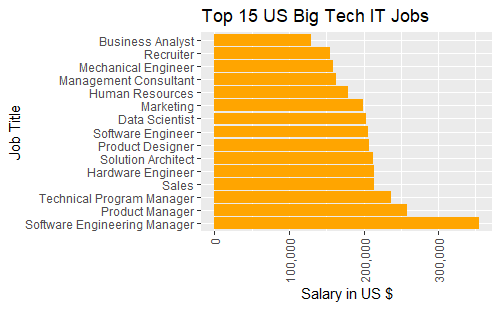

```r
require(scales)
  ggplot(data=highest_us_sal, aes(x=reorder(title, -avg_compensation),y=avg_compensation)) +
  geom_col(fill="orange", decreasing = TRUE) +
  scale_y_continuous() +
  xlab("Job Title") +
  ylab("Salary in US $")+
  scale_y_continuous(labels = comma) +
  theme(axis.text.x = element_text(angle = 90, vjust = 0.5, hjust=1)) +
    coord_flip() +
    ggtitle("Top 15 US Big Tech IT Jobs")
```

Here you can see that many of the average salaries in IT for big tech companies is around $200,000, with Software Engineering Manager coing in at the highest with over $350,000 on average. Is this similar for Europe?

```r
#Make a total compensation column

eu_salary <-
  eu_salary %>%
  mutate(compensation = salary + bonus_stock)
highest_eu_sal <-
  eu_salary %>%
  group_by(Position) %>%
  summarise(avg_compensation = mean(compensation)) %>%
  arrange(desc(avg_compensation)) %>%
  head(15)
highest_eu_sal
```

| Position | avg_compensation |
| --- | --- |
| Freelance AI lead / advisor | 400000 |
| Manager | 330000 |
| Tech Lead | 211000 |
| Sales | 210000 |
| Architect | 170000 |
| Software Sales | 170000 |
| Cloud Architect | 160000 |
| Project manager | 150000 |
| Teamlead | 150000 |
| BI Consultant SAP/ Data Engineer | 142000 |

[output cut: 5 more lines]

As the titles were input by users, many are different or slightly different spellings.

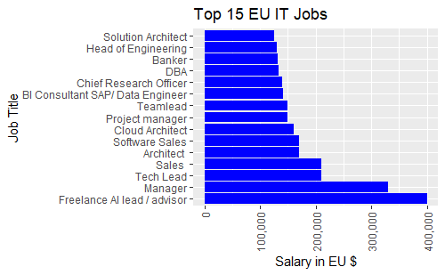

```r
  ggplot(data=highest_eu_sal, aes(x=reorder(Position, -avg_compensation),y=avg_compensation)) +
  geom_col(fill="blue", decreasing = TRUE) +
  scale_y_continuous() +
  xlab("Job Title") +
  ylab("Salary in EU $")+
  scale_y_continuous(labels = comma) +
  theme(axis.text.x = element_text(angle = 90, vjust = 0.5, hjust=1)) +
    coord_flip() +
  ggtitle("Top 15 EU IT Jobs")
```

In the EU dataset, there is more of a significant difference between wages. However, this can be attributed to the nature of how the data was recorded. In some cases in the EU dataset, there was only one person recording a certain title, so the wage for that job could be inflated (i.e Freelance AI Lead / advisor)

### Which States are paying the highest/lowest wages?

First I must add a state column that includes only the state abbreviation

```r
US_Salary <-
US_Salary %>%
  mutate(State = str_extract(string = location, pattern = "(?<!\\w)(?:,\\s+)?(?:A[LKZR]|C[AOT]|DE|FL|GA|HI|I[ADLN]|K[SY]|LA|M[EDAINSOT]|N[EVHJMYCD]|O[HKR]|PA|RI|S[CD]|T[NX]|UT|V[AT]|W[AIVY]),?\\s?(?!\\w)")) %>%
  filter( !is.na(State))
```

Next group by state and find average salary then plot

```r
state_compensation <-
  US_Salary %>%
  group_by(State) %>%
  summarise(avg_state_compensation = mean(totalyearlycompensation)) %>%
  arrange(desc(avg_state_compensation))

state_compensation
```

| State | avg_state_compensation |
| --- | --- |
| CA | 271510.76 |
| WA | 245112.41 |
| NY | 227358.48 |
| HI | 194000.00 |
| MA | 193514.38 |
| CO | 192476.27 |
| OR | 185047.10 |
| AR, | 184875.00 |
| NJ | 169752.17 |
| IL | 167324.29 |

[output cut: 58 more lines]

```
Mapping API still under development and may change in future releases.
Warning in standardName(x, stateAlternatives, ignore.case = ignore.case,  :
  20 items were not translated
```

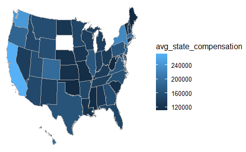

```r
mUSMap(state_compensation, key="State", fill = "avg_state_compensation")
```

Based on the plot we can see that the highest wages are in California, Washington, New York, Hawaii, and Massachusetts. Many of the lowest paying IT positions are in central US.

### 3. Which company pays the best wages overall?

```r
best_avg_comp_company <-
  US_Salary %>%
  group_by(company) %>%
  summarise(avg_compensation = mean(totalyearlycompensation)) %>%
  arrange(desc(avg_compensation)) %>%
  head(15)

best_avg_comp_company
```

| company | avg_compensation |
| --- | --- |
| Coupa software | 1483000.0 |
| Cloudkitchens | 700000.0 |
| amplitude | 680000.0 |
| Fireeye | 650000.0 |
| Doordash | 593500.0 |
| synaptics | 539000.0 |
| zillow group | 520000.0 |
| UBER | 506666.7 |
| PDT Partners | 500000.0 |
| snapchat | 485000.0 |

[output cut: 5 more lines]

```r
NA
```

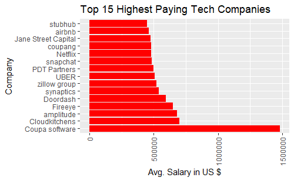

```r
  ggplot(data=best_avg_comp_company, aes(x=reorder(company, -avg_compensation),y=avg_compensation)) +
  geom_col(fill="red", decreasing = TRUE) +
  scale_y_continuous() +
  xlab("Company") +
  ylab("Avg. Salary in US $")+
  theme(axis.text.x = element_text(angle = 90, vjust = 0.5, hjust=1)) +
    coord_flip() +
    ggtitle("Top 15 Highest Paying Tech Companies")
```

Seeing as how I have never heard of a few of these companies, I can only assume that the average is so high due to there being few respondents from these companies. If this is the case, they may be founders/co-founders which could explain why their salaries are so high.

From the companies I recognize, Doordash is the highest paying company in the US. However, Zillow, Snapchat, Uber, Netflix, Airbnb, and stubhub all pay a similar average salary of around $500,000.

### Model that Predicts Wages

I would like to see if I can fit a model that predicts wages based on state, company, years of experience, and years at current company. However, to limit the number of factors I will only be looking at the big tech companies that I recognize in the US. If this model fits well, I will predict wages for a few different cases. We will not use the title variable as it takes a LONG time to fit with that variable (would be number of unique job titles minus 1 seperate predictors)

```r
# Select the companies
US_Tech_Sals <-
  US_Salary %>%
  filter(company=="Apple" | company=="Microsoft" | company=="Netflix" | company=="Facebook" | company=="Amazon" | company=="Google" | company=="Adobe" | company=="Uber" | company=="DoorDash")
```

### Fit the Model

```r
reg_mod <-
  lm(data = US_Tech_Sals, formula = totalyearlycompensation ~ State + company + yearsofexperience + yearsatcompany)
summary(reg_mod)
```

```
Call:
lm(formula = totalyearlycompensation ~ State + company + yearsofexperience +
    yearsatcompany, data = US_Tech_Sals)

Residuals:
    Min      1Q  Median      3Q     Max
-472837  -54248   -8139   36047 4513475

Coefficients:
                   Estimate Std. Error t value Pr(>|t|)
(Intercept)         97691.4    70421.5   1.387 0.165384
StateAR            -12046.0   110761.0  -0.109 0.913397
StateAR,             6132.1    88731.8   0.069 0.944904
StateAZ             17116.7    71722.5   0.239 0.811378
StateCA             59996.9    70075.3   0.856 0.391909
StateCO             16402.1    70842.6   0.232 0.816906
StateCT            -34618.6   140128.1  -0.247 0.804872
StateCT,           -44208.0   110776.4  -0.399 0.689842
StateFL            -47740.0    74005.0  -0.645 0.518875
StateGA             14310.7    71079.6   0.201 0.840440
StateHI             59518.3   110784.9   0.537 0.591106
StateIL            -13229.0    71417.2  -0.185 0.853046
StateIL,           -95051.3    75390.2  -1.261 0.207397
StateIN           -115765.5    85807.1  -1.349 0.177307
StateKS             35219.6   110774.9   0.318 0.750535
StateKY            -64426.3    92680.9  -0.695 0.486975
StateLA            -31613.0    92674.9  -0.341 0.733019
StateMA             32562.2    70340.3   0.463 0.643424
StateMA,            22945.5   110760.8   0.207 0.835885
StateMD            -12898.0    83739.7  -0.154 0.877591
StateMD,           -99499.4    74158.9  -1.342 0.179706
StateMI             -8112.5    74004.3  -0.110 0.912710
StateMI,          -173759.9   140128.1  -1.240 0.214986
StateMN              9547.4    73187.5   0.130 0.896211
StateMO            -42827.2    78363.7  -0.547 0.584715
StateMS             -8921.8   140100.7  -0.064 0.949225
StateNC             18604.3    72321.3   0.257 0.796992
StateND            -92997.7   110770.4  -0.840 0.401168
StateNH           -268522.2   140154.8  -1.916 0.055392
StateNH,          -135539.8    72193.8  -1.877 0.060471
```

[output cut: 81 more lines]

```
companyDoorDash   ***
companyFacebook   ***
companyGoogle     ***
companyMicrosoft  ***
companyNetflix    ***
companyUber       ***
yearsofexperience ***
yearsatcompany    ***
---
Signif. codes:
0 ‘***’ 0.001 ‘**’ 0.01 ‘*’ 0.05 ‘.’ 0.1 ‘ ’ 1

Residual standard error: 121300 on 21302 degrees of freedom
Multiple R-squared:  0.3806,    Adjusted R-squared:  0.3789
F-statistic: 225.7 on 58 and 21302 DF,  p-value: < 2.2e-16
```

State is not a significant factor in the model so lets try it without the State variable.

### Fitting model without state variable

```r
reg_no_state <-
  lm(data = US_Tech_Sals, formula = totalyearlycompensation ~ company + yearsofexperience + yearsatcompany)
summary(reg_no_state)
```

```
Call:
lm(formula = totalyearlycompensation ~ company + yearsofexperience +
    yearsatcompany, data = US_Tech_Sals)

Residuals:
    Min      1Q  Median      3Q     Max
-461371  -55744   -7407   36511 4516412

Coefficients:
                  Estimate Std. Error t value Pr(>|t|)
(Intercept)       142353.6     7023.2  20.269  < 2e-16 ***
companyAmazon       2916.6     7091.8   0.411   0.6809
companyApple       40806.0     7479.2   5.456 4.93e-08 ***
companyDoorDash    91293.1    13088.8   6.975 3.15e-12 ***
companyFacebook   125468.8     7343.4  17.086  < 2e-16 ***
companyGoogle      62213.5     7218.3   8.619  < 2e-16 ***
companyMicrosoft  -27934.1     7178.9  -3.891   0.0001 ***
companyNetflix    212397.4    10239.9  20.742  < 2e-16 ***
companyUber        93127.6     8210.7  11.342  < 2e-16 ***
yearsofexperience  11784.3      163.9  71.881  < 2e-16 ***
yearsatcompany      4543.2      311.0  14.609  < 2e-16 ***
---
Signif. codes:
0 ‘***’ 0.001 ‘**’ 0.01 ‘*’ 0.05 ‘.’ 0.1 ‘ ’ 1

Residual standard error: 122900 on 21350 degrees of freedom
Multiple R-squared:  0.363, Adjusted R-squared:  0.3627
F-statistic:  1217 on 10 and 21350 DF,  p-value: < 2.2e-16
```

Here, Amazon is technically not a significant factor, however since it is included in the company variable we will choose to leave it in the model. However, according to the adjusted R-squared value, only 36 percent of the variation in wages can be explained by this model.

Regardless, lets predict the wages of someone who works at DoorDash with 6 years of overall experience and 3 years at DoorDash.

### Predicting with the model

```r
predict(reg_no_state, data.frame(company = "DoorDash",yearsofexperience = 6, yearsatcompany = 3))
```

```
     1
317982
```

Based on our model, we predict that someone fitting this description would be making around $318,000 per year in total compensation.

### Faceting by company and looking at wages

```r
facet_plotting <-
  US_Tech_Sals %>%
  group_by(company,title) %>%
  summarize(mean_salary = mean(totalyearlycompensation)) %>%
  filter(title == "Hardware Engineer" | title =="Software Engineer" | title =="Recruiter" | title =="Marketing" | title =="Data Scientist")
facet_plotting
```

| company | title | mean_salary |
| --- | --- | --- |
| Adobe | Data Scientist | 260000.0 |
| Adobe | Hardware Engineer | 166000.0 |
| Adobe | Marketing | 222875.0 |
| Adobe | Recruiter | 182000.0 |
| Adobe | Software Engineer | 225873.1 |
| Amazon | Data Scientist | 236888.9 |
| Amazon | Hardware Engineer | 246736.8 |
| Amazon | Marketing | 195337.3 |
| Amazon | Recruiter | 150192.8 |
| Amazon | Software Engineer | 219317.8 |

[output cut: 33 more lines]

```r
NA
```

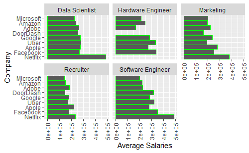

```r
facet_plotting %>%
  ggplot( aes(x=reorder(company,-mean_salary), y=mean_salary)) +
  geom_col(color = "green") +
  facet_wrap(~title) +
  theme(axis.text.x = element_text(angle = 90, vjust = 0.5, hjust=1)) +
    coord_flip() +
  scale_y_continuous() +
  xlab("Company") +
  ylab("Average Salaries")
```

### Alternate Way to visualize this data with pivoting

```r
SalariesWide <-
  US_Tech_Sals %>%
  group_by(company, title) %>%
  summarise(mean_salary = mean(totalyearlycompensation)) %>%
  pivot_wider(names_from = company, values_from = mean_salary)
SalariesWide
```

| title | Adobe | Amazon | Apple | DoorDash | Facebook | Google | Microsoft | Netflix | Uber |
| --- | --- | --- | --- | --- | --- | --- | --- | --- | --- |
| Business Analyst | 219250.0 | 140266.7 | 191000.0 | 193250.0 | 173458.3 | 209818.2 | 169850.0 | 250000.0 | 143636.4 |
| Data Scientist | 260000.0 | 236888.9 | 272506.7 | 254750.0 | 264913.8 | 273807.2 | 222475.2 | 484100.0 | 277466.7 |
| Hardware Engineer | 166000.0 | 246736.8 | 271949.7 | NA | 336764.7 | 283984.4 | 213817.2 | NA | 333666.7 |
| Human Resources | 311000.0 | 188103.4 | 279500.0 | NA | 227937.5 | 198560.0 | 166888.9 | 350000.0 | 268500.0 |
| Management Consultant | 149000.0 | 309545.5 | NA | 215000.0 | 177000.0 | 325200.0 | 213800.0 | NA | 139000.0 |
| Marketing | 222875.0 | 195337.3 | 281833.3 | 165666.7 | 250116.3 | 237195.1 | 201081.1 | 379600.0 | 191250.0 |
| Product Designer | 199111.1 | 217251.7 | 274480.0 | NA | 305388.9 | 290046.5 | 203488.1 | 342500.0 | 287360.0 |
| Product Manager | 269351.4 | 275773.3 | 297951.6 | 288000.0 | 457094.7 | 392485.0 | 246928.7 | 451444.4 | 382911.4 |
| Recruiter | 182000.0 | 150192.8 | 220750.0 | 146666.7 | 179654.5 | 179974.4 | 143000.0 | 233857.1 | 172250.0 |
| Sales | 388000.0 | 253069.8 | 55000.0 | NA | 214333.3 | 250595.2 | 329769.2 | NA | 311666.7 |

[output cut: 5 more lines]

```r
Avg_Salary_Companies <-
  US_Tech_Sals %>%
  group_by(title) %>%
  summarise(avg_salary = mean(totalyearlycompensation))
Average_Salaries <-
  SalariesWide %>%
  left_join(Avg_Salary_Companies, by = c("title" = "title"))
```